# Analysis of Credit Card Fraud

Thales Mello

December 3, 2015

# Analysis of Credit Card Fraud

In this report, we wish to analyze data to predict credit card analysis, based off the data from the [Introduction to Statistical Learning](http://www-bcf.usc.edu/~gareth/ISL/) book. Before we start, let’s load the necessary packages and initialize our script.

```r
require(readr)
require(dplyr)
```

```r
require(ggplot2)
require(caret)
require(rpart.plot)
require(doMC)
registerDoMC(4) # adjust number of cores for parallel computing
set.seed(1283) # set up seed so results are reproducible
```

We begin by downloading the data set and loading it in memory.

```r
if(!file.exists('Default.csv')){
  download.file('https://d1pqsl2386xqi9.cloudfront.net/notebooks/Default.csv', 'Default.csv', method = 'curl')
}
default <- read_csv('Default.csv') %>% select(default:income)
```

Then, we divide the our data in two sets, a train set and a test set.

```r
train_factor <- 0.5
in_train <- createDataPartition(default$default, p = train_factor, list = F)
train_set <- slice(default, in_train)
test_set <- slice(default, -in_train)
```

To get a feel of the data, let’s do an exploratory data analysis.

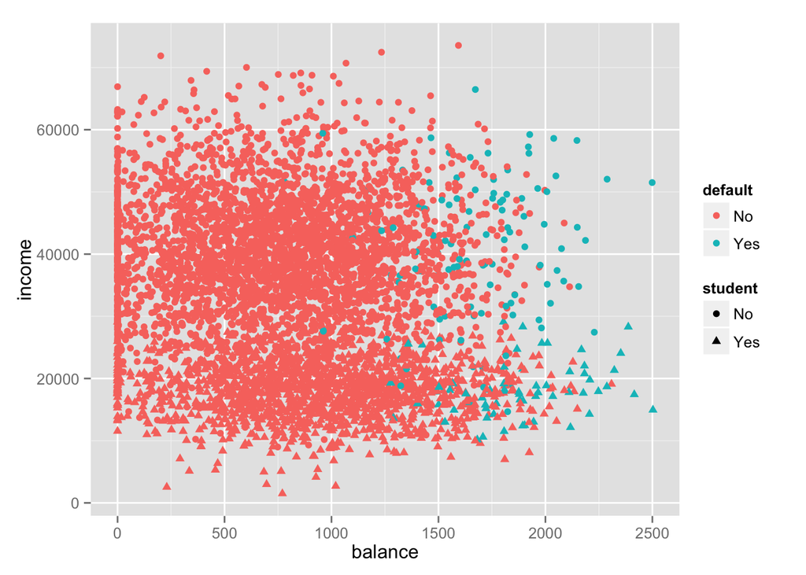

```r
qplot(balance, income, color = default, shape = student, data = train_set)
```

In the graph, the fraudulent credit cards are represented in blue, and we are trying to find a way to predict whether a card with given balance, income and student information is fraudulent or not. A naive approach would be to split the data in two with a vertical line. However, we can use some machine learning training methods to fit the data and find a model with a good accuracy of prediction.

## Fitting Decision Trees

We begin using the decision tree method because of its simplicity to interpret the fitted model. To train the model, we use the `caret` package in R, which provides a convenient API to train data using a variety of different machine learning methods.

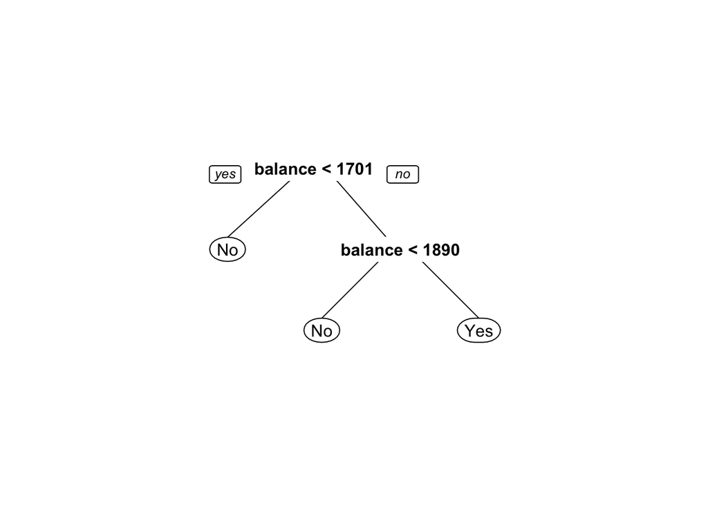

```r
fit_decision_tree <- train(default ~ ., method = 'rpart', data = train_set)
prp(fit_decision_tree$finalModel)
```

By analyzing the plot, we find the data is indeed better split by categorizing each point as non fraudulent if balance is smaller than 1889, or fraudulent otherwise. The other variables seem to have no influence on the output.

To visualize how this tree splits the data, we plot the train data graph again with the line that splits the data.

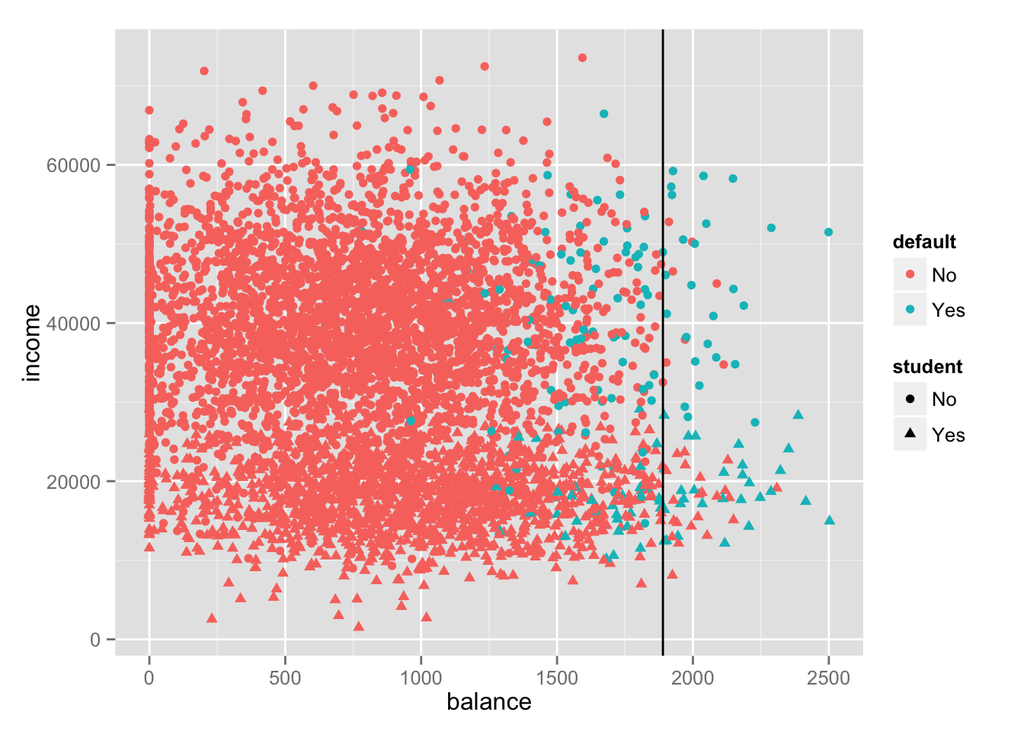

```r
split <- fit_decision_tree$finalModel$splits %>%
  subset(., row.names(.) == 'balance') %>%
  .[, 'index'] %>%
  max
qplot(balance, income, color = default, shape = student, data = train_set) +
  geom_vline(xintercept = split)
```

Finally, we want to compare the performance of the predictions gains the test data set. To do so, we compute the confusion matrix.

```r
prediction_decision_tree <- predict(fit_decision_tree, newdata = test_set)
confusionMatrix(prediction_decision_tree, test_set$default)
```

```
## Confusion Matrix and Statistics
##
##           Reference
## Prediction   No  Yes
##        No  4802   98
##        Yes   31   68
##
##                Accuracy : 0.9742
##                  95% CI : (0.9694, 0.9784)
##     No Information Rate : 0.9668
##     P-Value [Acc > NIR] : 0.001436
##
##                   Kappa : 0.5008
##  Mcnemar's Test P-Value : 6.211e-09
##
##             Sensitivity : 0.9936
##             Specificity : 0.4096
##          Pos Pred Value : 0.9800
##          Neg Pred Value : 0.6869
##              Prevalence : 0.9668
##          Detection Rate : 0.9606
##    Detection Prevalence : 0.9802
##       Balanced Accuracy : 0.7016
##
##        'Positive' Class : No
##
```

From the confusion matrix, we can see the accuracy of 97.42% is greater than the no information rate, which is the rate of non fraudulent points. In practice, it means this is a real improvement over not having a classification model. However, it’s still worthwhile to consider other methods.

## Random Forests

The second method we will try to apply to the data is the random forests method. Unfortunately, the interpretation of random forests isn’t usually as straightforward as the decision tree method, so we will analyze its efficacy of prediction directly with the confusion matrix.

```r
fit_random_forest <- train(default ~ ., method = 'rf', data = train_set)
prediction_rf <- predict(fit_decision_tree, newdata = test_set)
confusionMatrix(prediction_rf, test_set$default)
```

```
## Confusion Matrix and Statistics
##
##           Reference
## Prediction   No  Yes
##        No  4802   98
##        Yes   31   68
##
##                Accuracy : 0.9742
##                  95% CI : (0.9694, 0.9784)
##     No Information Rate : 0.9668
##     P-Value [Acc > NIR] : 0.001436
##
##                   Kappa : 0.5008
##  Mcnemar's Test P-Value : 6.211e-09
##
##             Sensitivity : 0.9936
##             Specificity : 0.4096
##          Pos Pred Value : 0.9800
##          Neg Pred Value : 0.6869
##              Prevalence : 0.9668
##          Detection Rate : 0.9606
##    Detection Prevalence : 0.9802
##       Balanced Accuracy : 0.7016
##
##        'Positive' Class : No
##
```

## Logistic Regression

Logistic regression uses a special form of linear regression designed to categorize data. Let’s explore it by fitting the data.

```r
fit_logistic <- train(default ~ ., method = 'glm', preProcess = c('center', 'scale'), data = train_set)
prediction_rf <- predict(fit_logistic, newdata = test_set)
confusionMatrix(prediction_rf, test_set$default)
```

```
## Confusion Matrix and Statistics
##
##           Reference
## Prediction   No  Yes
##        No  4814  102
##        Yes   19   64
##
##                Accuracy : 0.9758
##                  95% CI : (0.9711, 0.9799)
##     No Information Rate : 0.9668
##     P-Value [Acc > NIR] : 0.0001206
##
##                   Kappa : 0.5031
##  Mcnemar's Test P-Value : 9.018e-14
##
##             Sensitivity : 0.9961
##             Specificity : 0.3855
##          Pos Pred Value : 0.9793
##          Neg Pred Value : 0.7711
##              Prevalence : 0.9668
##          Detection Rate : 0.9630
##    Detection Prevalence : 0.9834
##       Balanced Accuracy : 0.6908
##
##        'Positive' Class : No
##
```

From the confusion matrix, we can see the accuracy is 97.58%, which is a marginal improvement over the previous methods. Let’s analyze the importance of the variables in each of the models to see if we can identify why this happens.

```r
varImp(fit_decision_tree)
```

```
## rpart variable importance
##
##            Overall
## balance    100.000
## income       3.315
## studentYes   0.000
```

```r
varImp(fit_random_forest)
```

```
## rf variable importance
##
##            Overall
## balance     100.00
## income       48.11
## studentYes    0.00
```

```r
varImp(fit_logistic)
```

```
## glm variable importance
##
##            Overall
## balance     100.00
## studentYes    8.71
## income        0.00
```

One possible explanation is the logistic regression method could find a predictive value for the `student` variable.

## Conclusion

In this report, we use the decision tree, random forests and logistic regression methods to model our data. Then we compare the performance of each models’ gains the a test data set. Even though the logistic regression method yielded the model with the highest accuracy, the accuracy gain was only marginal. It exemplifies the principle in machine learning of reducing marginal gains when you add complexity to your model. That is, if you improve your model, you tend to not have much improvement on accuracy.